# S4: a short guide for the perplexed

This document is the implementation of an excellent blog post “[S4: a short guide for the perplexed](https://stuartlee.org/2019/07/09/s4-short-guide/)” by [Stuart Lee](https://stuartlee.org/about/) ( [Source Rmd file](https://github.com/sa-lee/stuartlee.org/blob/abcd1475c869ff8b1ec056aa766e422f058f1028/content/post/2019-07-02-s4/index.Rmd) ). More S4 resources are available at the S4-Bioconductor repo by [Malte Thodberg](https://github.com/MalteThodberg).

## What is S4?

S4 is a formal object oriented system in R, it’s named S4 since it was a part of version four of S language. It’s implemented in the `methods` package created by John Chambers and maintained by the R core team. It also is one of several packages that ships with base R and is loaded on start up.

## Why use S4?

Compared to other object oriented paradigms in R, S4 requires a developer to write classes that follow a strict structure - an S4 object has its components defined upfront using slots. A well designed class can avoid code duplication, and the strictness helps a developer to ensure their code is correct. As will we see later, defining an S4 class requires components and their types to be declared upfront, meaning that S4 classes are also self-documenting.

As with any other programming language or paradigm, you may have to use S4 because everyone else is using it. Take the Bioconductor project for example. They have defined standard S4 classes in their ecosystem to represent many types of ‘omics’ data. Developers are strongly nudged use these classes and their associated methods. This has two massive benefits: firstly, a developer doesn’t need to invent their own class and secondly, it enables interoperability between many different packages.

Learning to program with S4 can be daunting - especially for new users of R or those who are used to the relative simplicity of the tidyverse ecosystem. I remember being incredibly confused and overwhelmed when I started to learn it (a lot of the documentation and guides are extremely technical) and found myself reading a lot of other people’s code in order to figure out what on earth is going on. From both a developer and user perspective, I think the essence of S4 can be distilled into three principles.

## The Big Picture Design Principles of S4

### Principle 1: it’s all about the abstraction

> S4 objects don't do anything; they are pure data. Accepting that is the first step towards mastery of OOP in [#rstats](https://twitter.com/hashtag/rstats?src=hash&ref_src=twsrc%5Etfw).

> — Michael Lawrence (@lawremi) [August 14, 2015](https://twitter.com/lawremi/status/632273174160277504?ref_src=twsrc%5Etfw)

The design of an S4 class is merely a way of setting up an abstraction for a data analysis problem. This is often the hardest part of using S4, coming up with a ‘good-enough’ abstraction for the problem at hand.

We can define a class to represent a Turtle as follows:

```r
library(methods)
setClass("Turtle",
         slots = c(location = "numeric",
                   orientation = "numeric",
                   path = "matrix")
)
```

At a minimum an S4 class needs two things the name of the class and a named character vector of slots. Slots define the data that forms the class. In the case of the Turtle, we have three slots one representing the turtle’s current location as a numeric vector, one representing it’s current orientation (the angle that the turtle is facing), and finally a matrix representing the path it’s travelled so far.

We can create an instance of a Turtle using `new`:

```r
lil_turtle <- new("Turtle",
                  location = c(0,0),
                  orientation = 0,
                  path = matrix(c(0,0), ncol = 2))
lil_turtle
```

```
## An object of class "Turtle"
## Slot "location":
## [1] 0 0
##
## Slot "orientation":
## [1] 0
##
## Slot "path":
##      [,1] [,2]
## [1,]    0    0
```

Slots can be accessed using `@` but we will see later it’s better to define functions called getters that access each component of the object.

```r
lil_turtle@location
```

```
## [1] 0 0
```

```r
lil_turtle@orientation
```

```
## [1] 0
```

```r
lil_turtle@path
```

```
##      [,1] [,2]
## [1,]    0    0
```

```r
okTurtle <- function(object) {
  # check location has length 2
  loc_ln <- length(object@location)
  # check orientation is between -360 to 360 and has length one
  orientation <- object@orientation
  # check path is a numeric matrix
  path <- object@path
  c(if (loc_ln != 2) "location must have length two.",
    if (length(orientation) != 1) "orientation must have length one.",
    if (abs(orientation) > 360) paste("orientation angle", orientation, "must be between -360 and 360 degrees."),
    if (mode(path) != "numeric") "path must be a numeric matrix",
    if (ncol(path) != 2) "path must have two columns"
  )
  TRUE
}
setValidity("Turtle", okTurtle)
```

```
## Class "Turtle" [in ".GlobalEnv"]
##
## Slots:
##
## Name:     location orientation        path
## Class:     numeric     numeric      matrix
```

Finally, we need an interface to creating a objects of class Turtle. This is called a constructor. Generally, this is a function that calls `new` and has arguments corresponding to the slots of our object.

```r
Turtle <- function(location = c(0,0), orientation = 0) {
  new("Turtle",
      location = location,
      orientation = orientation,
      path = matrix(location, ncol = 2))
}
```

Note that it’s a convention when using S4 to use CamelCase (I don’t make the rules!).

So far we can’t do anything interesting with turtles, we need to define some methods!

### Principle 2: in statistics we like functions

Both S3 and S4 use generic functions which is a little different from other object-oriented programming languages (it is a variety of [ad-hoc polymorphism](https://en.wikipedia.org/wiki/Ad_hoc_polymorphism) if you like that kind of thing). A generic function determines how a method is called when an argument is a given class (or combination of classes). In general, a generic function should be created if you plan to reuse it for many distinct classes or if it will be useful to other package developers.

For example, we could create two generic functions that represent a turtle moving forward and a turtle turning.

```r
setGeneric("forward",
           function(x, ...) standardGeneric("forward")
)
```

```
## [1] "forward"
```

This creates a function called `forward` with an argument `x`, called the signature of the generic and `...` which can be other arguments that will determine how a turtle moves. The class of `x` changes which `forward` method will be selected.

Similarly, we can implement a generic for reorienting a turtle.

```r
setGeneric("turn", function(x, ...) standardGeneric("turn"))
```

```
## [1] "turn"
```

To complete our interface, we will also create generics for accessing and replacing each slot of our class.

```r
setGeneric("location", function(x) standardGeneric("location"))
```

```
## [1] "location"
```

```r
setGeneric("location<-", function(x, value) standardGeneric("location<-"))
```

```
## [1] "location<-"
```

```r
setGeneric("orientation", function(x) standardGeneric("orientation"))
```

```
## [1] "orientation"
```

```r
setGeneric("orientation<-", function(x, value) standardGeneric("orientation<-"))
```

```
## [1] "orientation<-"
```

```r
setGeneric("path", function(x) standardGeneric("path"))
```

```
## [1] "path"
```

```r
setGeneric("path<-", function(x, value) standardGeneric("path<-"))
```

```
## [1] "path<-"
```

We now have a bunch of generics next we need to create methods for our turtle. Let’s start simple with our getter functions. To create a method, we use `setMethod` with : * the name of our generic * an argument called ‘signature’, that tells us the class the generic will dispatch on * a function that tells us what the method does

```r
setMethod("location", signature = "Turtle", function(x) x@location)
setMethod("orientation", signature = "Turtle", function(x) x@orientation)
setMethod("path", signature = "Turtle", function(x) x@path )
```

We can also create our replacement methods, these will update each slot. A turtle’s orientation and path are always updated relative to where they already are positioned.

```r
setMethod("location<-", signature = "Turtle", function(x, value) {
  x@location <- value
  stopifnot(validObject(x))
  x
})
setMethod("orientation<-", signature = "Turtle", function(x, value) {
  x@orientation <- orientation(x) + value
  stopifnot(validObject(x))
  x
})
setMethod("path<-", "Turtle", function(x, value) {
  x@path <- rbind(path(x), matrix(value, ncol = 2))
  stopifnot(validObject(x))
  x
})
```

Now we can implement methods for forward and turn:

```r
setMethod("forward", signature = "Turtle",
          function(x, steps) {
            location <- location(x)
            angle <- orientation(x) * pi / 180
            x_dir <- steps * cos(angle)
            y_dir <- steps * sin(angle)

            new_location <- c(location[1] + x_dir,
                              location[2] + y_dir)

            location(x) <- new_location
            path(x) <- new_location

            x
          })
setMethod("turn", "Turtle", function(x, angle) {
  orientation(x) <- angle
  x
})
```

Most of the time, you probably don’t need a new generic function but rather to reuse an existing one (for Bioconductor packages generic functions are contained in the `BiocGenerics` package) by setting a method for your class. For example, maybe we want a prettier printing method for our turtle, for S4 classes, the print method is called “show”:

```r
setMethod("show", "Turtle",
          function(object) {
            utf8::utf8_print(paste("\U1F422",
                                   paste("Located at:", paste(round(location(object), 1), collapse = ",")),
                                   paste("Facing:", orientation(object), "degrees"),
                                   collapse = "\n"))
          })
lil_turtle
```

```
## [1] "🐢 Located at: 0,0 Facing: 0 degrees"
```

When designing a new class it’s a good idea to target methods for generic functions that are in the base API. This ensures portability of your code and means that your class behaves in a way that is already familiar to a user.

Now we have implemented enough methods to make our turtle move, we can start getting our turtle to move around in 2-d! For example, we could move in a triangle:

```r
library(magrittr)
turtle <- Turtle()
turtle <- turtle %>%
  turn(angle = 60) %>%
  forward(steps = 3) %>%
  turn(angle = -120) %>%
  forward(steps = 3) %>%
  turn(angle = -120) %>%
  forward(steps = 3)
turtle
```

```
## [1] "🐢 Located at: 0,0 Facing: -180 degrees"
```

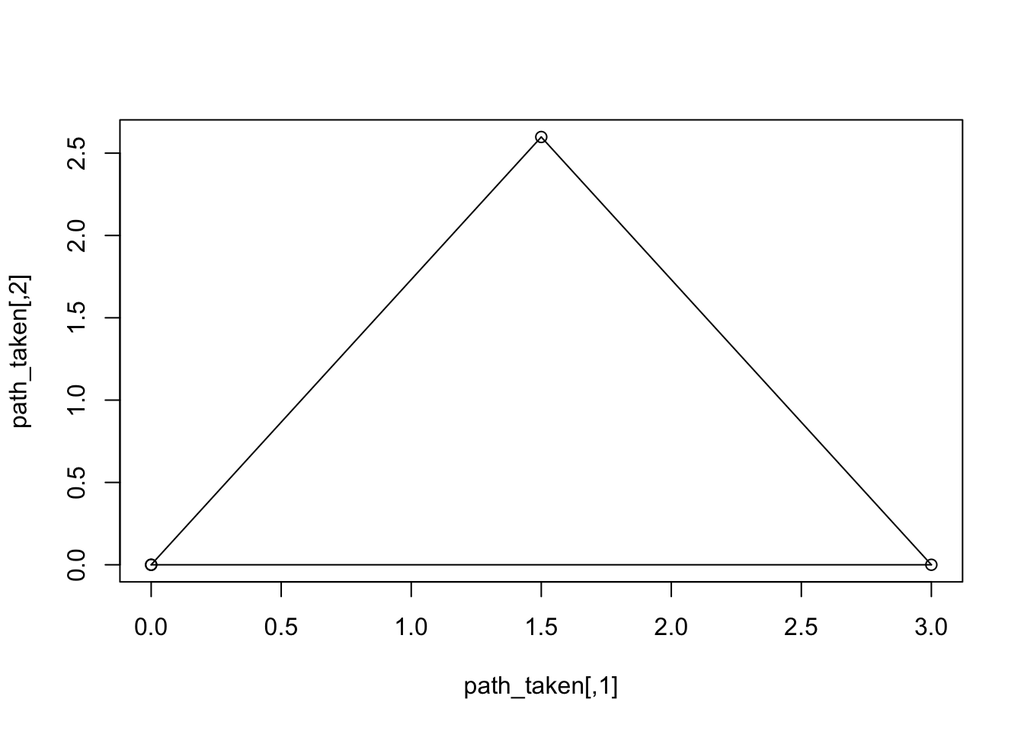

```r
path_taken <- path(turtle)
plot(path_taken)
segments(path_taken[1:3,1],
         path_taken[1:3,2],
         path_taken[2:4, 1],
         path_taken[2:4, 2])
```

### Principle 3: designing is hard, reuse instead!

> If you're going to have a big multi-site collaboration, the language you're going to use isn't what you need to agree on. They key is stadardizing data structures. - Robert Gentleman [#Bioc2019](https://twitter.com/hashtag/Bioc2019?src=hash&ref_src=twsrc%5Etfw) [#RGentlemanSymposium](https://twitter.com/hashtag/RGentlemanSymposium?src=hash&ref_src=twsrc%5Etfw)

> — Gabe Becker (@groundwalkergmb) [June 27, 2019](https://twitter.com/groundwalkergmb/status/1144325071672107008?ref_src=twsrc%5Etfw)

In R there is usually package for the task you would like to perform. Similarly, when using S4 somebody has probably done the hard work of designing a class related to an analysis or problem at hand. In Bioconductor, the community has standardised core data structures related to all aspects of ‘omics’, with two key examples being the `SummarizedExperiment` and `Ranges` classes. Instead of inventing your own class you can extend (or just use) other package’s data structures. If the class has been implemented well, you won’t have to go through the boring process of implementing an interface such as making setters and getters.

Let’s extend our Turtle class, to a Turtle that’s holding a pen. A turtle holding a pen will include three new slots: colour, thickness, and an on/off switch.

```r
setClass("TurtleWithPen",
         slots = c(colour = "character", thickness = "numeric", on = "logical"),
         contains = "Turtle")
```

The argument `contains = "Turtle"` tells `setClass` we are inheriting from the `Turtle` class. A `TurtleWithPen` is still a `Turtle` but has additional slots corresponding to a Pen. We can write a constructor for a Turtle holding a pen:

```r
TurtleWithPen <- function(x, colour = "pink", thickness = 1, on = FALSE) {
  new("TurtleWithPen", colour = colour, thickness = thickness, on = on, x)
}
turtle <- TurtleWithPen(Turtle())
turtle
```

```
## [1] "🐢 Located at: 0,0 Facing: 0 degrees"
```

```r
class(turtle)
```

```
## [1] "TurtleWithPen"
## attr(,"package")
## [1] ".GlobalEnv"
```

Our `TurtleWithPen` inherits all the methods associated with Turtle, including `show` which is why the displayed object looks the same. All the same moves we made with an ordinary turtle can be made by one holding a pen:

```r
turtle %>%
  turn(angle = 60) %>%
  forward(steps = 3) %>%
  turn(angle = -120) %>%
  forward(steps = 3) %>%
  turn(angle = -120) %>%
  forward(steps = 3)
```

```
## [1] "🐢 Located at: 0,0 Facing: -180 degrees"
```

Now we want to modify the `show` method, if the pen is on, then will animate the Turtle’s path, otherwise we will show the Turtle has normal.

```r
setMethod("show", "TurtleWithPen",
          function(object) {
            if (object@on) {
              path <- path(object)
              colnames(path) <- c("x", "y")
              path_tbl <- data.frame(path, id = seq_len(nrow(path)))
              plot <- ggplot2::ggplot(data = path_tbl) +
                ggplot2::geom_path(ggplot2::aes(x, y),
                                   colour = object@colour,
                                   size = object@thickness) +
                ggplot2::theme_void() +
                gganimate::transition_reveal(id)
              gganimate::animate(plot)
            } else {
              callNextMethod()
            }
          })
```

Now the show method will animate, if the pen is switched on, otherwise we will call the regular Turtle method.

We can try this out by having our Turtle walk through an equilateral triangle:

```r
pendown <- function(x) {
  x@on <- TRUE
  x
}
penup <- function(x) {
  x@on <- FALSE
  x
}
turtle <- turtle %>%
  pendown() %>%
  turn(angle = 60) %>%
  forward(steps = 3) %>%
  turn(angle = -120) %>%
  forward(steps = 3) %>%
  turn(angle = -120) %>%
  forward(steps = 3)
turtle %>%
  show()
```

[output not shown]

But if we put the pen up, then we get the usual `show` method:

```r
turtle %>%
  penup()
```

```
## [1] "🐢 Located at: 0,0 Facing: -180 degrees"
```

[output not shown]

## Wrapping up

The somewhat silly turtle graphics example has been my attempt at demystifying S4 programming:

- S4 classes by themselves are just data, to compute with them you need to write methods.
- Methods are just functions that are set on a class and are constructed from generic functions.
- Reusing classes and methods enable a user and developer to minimise code duplication via inheritance.

```r
star_pupil <- TurtleWithPen(Turtle(c(30,30), -100),
                            colour = "green", thickness = 2)
draw_star <- function(x) {
  x <- forward(x, steps = 30)
  for (i in 1:8) {
    x <- turn(x, angle = 140)
    x <- forward(x, steps = 30)
    x <- turn(x, angle = -100)
    x <- forward(x, steps = 30)
  }
  x <- turn(x, angle = 140)
  forward(x, steps = 30)
}
star_pupil %>%
  pendown() %>%
  draw_star() %>%
  show()
```

[output not shown]

### Where to find out more?

This post has barely scratched the surface of what S4 can do. We haven’t really touched on the ideas of multiple inheritance or multiple dispatch. Hopefully though if you’re new to S4, the ideas behind it are a little less scary!

There are several resources for learning more about S4:

- These [course](https://bioconductor.org/help/course-materials/2017/Zurich/S4-classes-and-methods.html) notes by Martin Morgan and Hervè Pagès go into detail about what you need to use S4 in a package.
- Hadley Wickham’s Advanced R book has a section on [S4](http://adv-r.had.co.nz/S4.html) (and [here](https://adv-r.hadley.nz/s4.html)) and other types of object-oriented programming in R.
- If you want to get into the nitty-gritty technicalities of S4 programming, take a look at John Chamber’s [Software for Data Analysis](https://www.springer.com/gp/book/9780387759357).
- Looking in the wild. Two examples of non-Bioconductor packages that make use of S4 are the [`Matrix`](https://cran.r-project.org/web/packages/Matrix/index.html) and [`rstan`](https://github.com/stan-dev/rstan/wiki/RStan-Getting-Started).